# Self-Labeling Analysis

2023-09-26

Pre-registration: https://osf.io/mxnbu/

```r
## Load packages
library(tidyverse)
library(here)
library(kableExtra)
library(scales)
library(oddsratio)
library(broom)
## Load data
df <- readRDS(here("Clean Data.rds"))

## Set functions
`%+%` <- paste0

percents <- function(x) {

  df %>%
    count({{x}}) %>%
    mutate(pct = percent(n / sum(n), .1)) %>%
    kable() %>%
    kable_styling() %>%
    return()

}

percents_by_group <- function(x, g) {

  df %>%
    count({{g}}, {{x}}) %>%
    mutate(pct = percent(n / sum(n))) %>%
    group_by({{g}}) %>%
    mutate(group_pct = percent(n / sum(n), .1)) %>%
    kable() %>%
    kable_styling() %>%
    return()

}
```

# Sample Description

## Self-Labeling

```r
percents(depression_self_id)
```

| depression_self_id | n | pct |
| --- | --- | --- |
| FALSE | 1107 | 77.8% |
| TRUE | 316 | 22.2% |

```r
percents(PHQ8_cutoff)
```

| PHQ8_cutoff | n | pct |
| --- | --- | --- |
| FALSE | 824 | 57.9% |
| TRUE | 599 | 42.1% |

```r
percents(depression_dx)
```

| depression_dx | n | pct |
| --- | --- | --- |
| FALSE | 1164 | 81.8% |
| TRUE | 259 | 18.2% |

```r
percents_by_group(depression_self_id, PHQ8_cutoff)
```

| PHQ8_cutoff | depression_self_id | n | pct | group_pct |
| --- | --- | --- | --- | --- |
| FALSE | FALSE | 758 | 53.3% | 92.0% |
| FALSE | TRUE | 66 | 4.6% | 8.0% |
| TRUE | FALSE | 349 | 24.5% | 58.3% |
| TRUE | TRUE | 250 | 17.6% | 41.7% |

```r
chisq.test(df$depression_self_id, df$PHQ8_cutoff)
```

```
##
##  Pearson's Chi-squared test with Yates' continuity correction
##
## data:  df$depression_self_id and df$PHQ8_cutoff
## X-squared = 226.44, df = 1, p-value < 2.2e-16
```

```r
percents_by_group(depression_self_id, depression_dx)
```

| depression_dx | depression_self_id | n | pct | group_pct |
| --- | --- | --- | --- | --- |
| FALSE | FALSE | 1044 | 73.4% | 89.7% |
| FALSE | TRUE | 120 | 8.4% | 10.3% |
| TRUE | FALSE | 63 | 4.4% | 24.3% |
| TRUE | TRUE | 196 | 13.8% | 75.7% |

```r
chisq.test(df$depression_self_id, df$depression_dx)
```

```
##
##  Pearson's Chi-squared test with Yates' continuity correction
##
## data:  df$depression_self_id and df$depression_dx
## X-squared = 520.22, df = 1, p-value < 2.2e-16
```

## Demographics

```r
df %>%
  summarize(mean_age = mean(age),
            sd_age = sd(age)) %>%
  kable() %>%
  kable_styling()
```

| mean_age | sd_age |
| --- | --- |
| 18.92973 | 1.114718 |

```r
percents(gender)
```

| gender | n | pct |
| --- | --- | --- |
| Cis Female | 909 | 63.9% |
| Cis Male | 397 | 27.9% |
| TGD | 117 | 8.2% |

```r
percents(race_ethnicity)
```

| race_ethnicity | n | pct |
| --- | --- | --- |
| White non-Hispanic | 820 | 57.6% |
| AI/AN non-Hispanic | 4 | 0.3% |
| Asian non-Hispanic | 195 | 13.7% |
| Black non-Hispanic | 98 | 6.9% |
| NH/PI non-Hispanic | 2 | 0.1% |
| ME/NA non-Hispanic | 42 | 3.0% |
| Other or Multiracial non-Hispanic | 56 | 3.9% |
| Hispanic | 206 | 14.5% |

```r
percents(family_income)
```

| family_income | n | pct |
| --- | --- | --- |
| Below U.S. Median | 345 | 24.2% |
| Above U.S. Median | 1078 | 75.8% |

# RQ 1: Are demographic characteristics associated with depression self-labeling?

We will assess the relationship between demographic characteristics via logistic regressions where self-labeling is the dependent variable and the demographic variable is the independent variable. We will report odds ratios for each demographic variable on self-labeling both without (4 regressions) and with (4 additional regressions) depression symptom severity as a covariate.

Missing data: Imputed with missForest algorithm. Multiple comparison adjustment: False discovery rate with α set to .05

```r
demographics <- c(
  "age",
  "gender",
  "race_ethnicity",
  "family_income"
)

rq_1_uncontrolled <- tibble()
rq_1_controlled <- tibble()

for(x in demographics) {

  if(x == "race_ethnicity") {

    model_data <- df %>%
      filter(!race_ethnicity %in% c("AI/AN non-Hispanic", "NH/PI non-Hispanic"))

  } else model_data <- df

  # Set formulas
  formula_uncontrolled <- as.formula("depression_self_id ~ " %+% x)
  formula_controlled <- as.formula("depression_self_id ~ " %+% x %+% "+ PHQ8")

  # Run logistic regressions
  glm_uncontrolled <- glm(data = model_data, formula = formula_uncontrolled, family = "binomial")
  glm_controlled <- glm(data = model_data, formula = formula_controlled, family = "binomial")

  # Save coefficients and p-values
  coef_uncontrolled <- tidy(glm_uncontrolled)
  coef_controlled <- tidy(glm_controlled)

  # Save odds ratios and confidence intervals
  or_uncontrolled <- or_glm(data = model_data, model = glm_uncontrolled, incr = list(age = 1), ci = .95)
  or_controlled <- or_glm(data = model_data, model = glm_controlled, incr = list(age = 1, PHQ8 = 1), ci = .95)

  # Combine coefficients, p-values, odds ratios, and confidence intervals
  glm_output_uncontrolled <- inner_join(coef_uncontrolled, or_uncontrolled, by = c("term" = "predictor"))
  glm_output_controlled <- inner_join(coef_controlled, or_controlled, by = c("term" = "predictor"))

  # Attach output to larger table
  rq_1_uncontrolled <- rbind(rq_1_uncontrolled, glm_output_uncontrolled)
  rq_1_controlled <- rbind(rq_1_controlled, glm_output_controlled)

}

# Adjust p-values
rq_1_uncontrolled$p_adj <- p.adjust(rq_1_uncontrolled$p.value, method = "fdr")
rq_1_controlled$p_adj <- p.adjust(rq_1_controlled$p.value, method = "fdr")

# Table 2
rq_1_uncontrolled %>%
  left_join(rq_1_controlled, by = "term") %>%
  mutate(
    across(c(starts_with("oddsratio"), starts_with("ci_")),
           ~ round(., 2)),
    or_uncontrolled = oddsratio.x %+% " (" %+% `ci_low (2.5).x` %+% ", " %+% `ci_high (97.5).x` %+% ")",
    p_adj_uncontrolled = round(p_adj.x, 3),
    or_controlled = oddsratio.y %+% " (" %+% `ci_low (2.5).y` %+% ", " %+% `ci_high (97.5).y` %+% ")",
    p_adj_controlled = round(p_adj.y, 3)
  ) %>%
  select(term, or_uncontrolled:p_adj_controlled) %>%
  kable() %>%
  kable_styling()
```

| term | or_uncontrolled | p_adj_uncontrolled | or_controlled | p_adj_controlled |
| --- | --- | --- | --- | --- |
| age | 1.35 (1.21, 1.5) | 0.000 | 1.39 (1.23, 1.58) | 0.000 |
| genderCis Male | 0.47 (0.33, 0.64) | 0.000 | 0.77 (0.52, 1.1) | 0.220 |
| genderTGD | 1.73 (1.15, 2.59) | 0.015 | 1.52 (0.94, 2.43) | 0.138 |
| race_ethnicityAsian non-Hispanic | 0.39 (0.24, 0.62) | 0.000 | 0.37 (0.21, 0.61) | 0.000 |
| race_ethnicityBlack non-Hispanic | 1.05 (0.64, 1.69) | 0.828 | 0.67 (0.37, 1.17) | 0.220 |
| race_ethnicityME/NA non-Hispanic | 0.84 (0.37, 1.71) | 0.731 | 0.65 (0.26, 1.49) | 0.391 |
| race_ethnicityOther or Multiracial non-Hispanic | 1.34 (0.73, 2.39) | 0.423 | 1.23 (0.62, 2.37) | 0.594 |
| race_ethnicityHispanic | 0.74 (0.5, 1.08) | 0.186 | 0.55 (0.35, 0.84) | 0.013 |
| family_incomeAbove U.S. Median | 0.63 (0.48, 0.83) | 0.002 | 0.96 (0.7, 1.33) | 0.800 |

# RQ 2: What is the relationship between self-labeling as being depressed and self-management strategies (emotion coping strategies, treatment efficacy beliefs)?

Missing data: Imputed with missForest algorithm. Multiple comparison adjustment: False discovery rate with α set to .05

```r
# RQ 2
outcomes <- c(
  "perceived_control",
  "CERQ_self_blame",
  "CERQ_other_blame",
  "CERQ_rumination",
  "CERQ_catastrophizing",
  "CERQ_perspective",
  "CERQ_refocusing",
  "CERQ_reappraising",
  "CERQ_acceptance",
  "CERQ_planning",
  "MHSAS_therapy",
  "MHSAS_medication"
)

rq_2_uncontrolled <- tibble()
rq_2_controlled <- tibble()

for(y in outcomes) {

  model_data <- df

  # Set formulas
  formula_uncontrolled <- as.formula(y %+% "~ depression_self_id")
  formula_controlled <- as.formula(y %+% "~ depression_self_id + PHQ8")

  # Run logistic regressions
  lm_uncontrolled <- lm(data = model_data, formula = formula_uncontrolled)
  lm_controlled <- lm(data = model_data, formula = formula_controlled)

  # Save coefficients and p-values
  coef_uncontrolled <- tidy(lm_uncontrolled) %>%
    mutate(ci_low = estimate - (1.96 * std.error),
           ci_high = estimate + (1.96 * std.error)) %>%
    filter(term != "(Intercept)")
  coef_controlled <- tidy(lm_controlled) %>%
    mutate(ci_low = estimate - (1.96 * std.error),
           ci_high = estimate + (1.96 * std.error)) %>%
    filter(term != "(Intercept)")

  # Attach DV information
  coef_uncontrolled$dv <- y
  coef_controlled$dv <- y

  # Attach output to larger table
  rq_2_uncontrolled <- rbind(rq_2_uncontrolled, coef_uncontrolled)
  rq_2_controlled <- rbind(rq_2_controlled, coef_controlled)

}

# Adjust p-values
rq_2_uncontrolled$p_adj <- p.adjust(rq_2_uncontrolled$p.value, method = "fdr")
rq_2_controlled$p_adj <- p.adjust(rq_2_controlled$p.value, method = "fdr")

# Table 3
rq_2_uncontrolled %>%
  inner_join(rq_2_controlled, by = c("term", "dv")) %>%
  mutate(
    across(c(starts_with("estimate"), starts_with("ci_")),
           ~ round(., 2)),
    est_uncontrolled = estimate.x %+% " (" %+% ci_low.x %+% ", " %+% ci_high.x %+% ")",
    p_adj_uncontrolled = round(p_adj.x, 3),
    est_controlled = estimate.y %+% " (" %+% ci_low.y %+% ", " %+% ci_high.y %+% ")",
    p_adj_controlled = round(p_adj.y, 3)
  ) %>%
  select(dv, est_uncontrolled:p_adj_controlled) %>%
  kable() %>%
  kable_styling()
```

| dv | est_uncontrolled | p_adj_uncontrolled | est_controlled | p_adj_controlled |
| --- | --- | --- | --- | --- |
| perceived_control | -0.4 (-0.51, -0.28) | 0.000 | -0.22 (-0.36, -0.09) | 0.002 |
| CERQ_self_blame | 0.37 (0.24, 0.5) | 0.000 | -0.07 (-0.2, 0.07) | 0.406 |
| CERQ_other_blame | 0.12 (0, 0.23) | 0.045 | 0.01 (-0.11, 0.14) | 0.897 |
| CERQ_rumination | 0.51 (0.39, 0.63) | 0.000 | 0.14 (0.01, 0.27) | 0.057 |
| CERQ_catastrophizing | 0.47 (0.35, 0.59) | 0.000 | 0.18 (0.05, 0.31) | 0.013 |
| CERQ_perspective | -0.27 (-0.4, -0.15) | 0.000 | -0.37 (-0.51, -0.22) | 0.000 |
| CERQ_refocusing | -0.3 (-0.42, -0.17) | 0.000 | -0.24 (-0.38, -0.1) | 0.002 |
| CERQ_reappraising | -0.44 (-0.56, -0.31) | 0.000 | -0.29 (-0.43, -0.15) | 0.000 |
| CERQ_acceptance | 0.34 (0.22, 0.47) | 0.000 | 0 (-0.13, 0.14) | 0.992 |
| CERQ_planning | -0.3 (-0.42, -0.17) | 0.000 | -0.16 (-0.3, -0.02) | 0.040 |
| MHSAS_therapy | 0.07 (-0.04, 0.19) | 0.213 | 0.08 (-0.05, 0.21) | 0.281 |
| MHSAS_medication | 0.39 (0.27, 0.51) | 0.000 | 0.39 (0.25, 0.52) | 0.000 |

# Secondary Analyses

RQ 2: We may explore non-linear relationships between depression self-labeling, symptom severity, and self-management strategies, e.g., by controlling for symptom severity using a quadratic term, or by conducting further analyses that only examine the relationship between self-labeling and self-management strategies among students with a limited range of depression symptom severity (e.g., only students who meet the clinical cutoff for depression; only students who experience any depression symptoms; only students “at the margin” who are not clearly depressed or not depressed).

```r
# The relationship between self-labeling and perceived control appears to be moderated by depression symptom severity
lm(
  data = df,
  formula = perceived_control ~ depression_self_id * PHQ8
) %>%
  summary()
```

```
##
## Call:
## lm(formula = perceived_control ~ depression_self_id * PHQ8, data = df)
##
## Residuals:
##     Min      1Q  Median      3Q     Max
## -3.5619 -0.6328  0.0585  0.6417  2.1932
##
## Coefficients:
##                              Estimate Std. Error t value Pr(>|t|)
## (Intercept)                  0.377908   0.045874   8.238 3.94e-16 ***
## depression_self_idTRUE       0.123946   0.155078   0.799 0.424281
## PHQ8                        -0.018192   0.004993  -3.643 0.000279 ***
## depression_self_idTRUE:PHQ8 -0.026786   0.010787  -2.483 0.013131 *
## ---
## Signif. codes:  0 '***' 0.001 '**' 0.01 '*' 0.05 '.' 0.1 ' ' 1
##
## Residual standard error: 0.9349 on 1419 degrees of freedom
## Multiple R-squared:  0.05298,    Adjusted R-squared:  0.05097
## F-statistic: 26.46 on 3 and 1419 DF,  p-value: < 2.2e-16
```

# Plots

Outcomes by self-labeling and PHQ-8, smoothed

[output not shown]

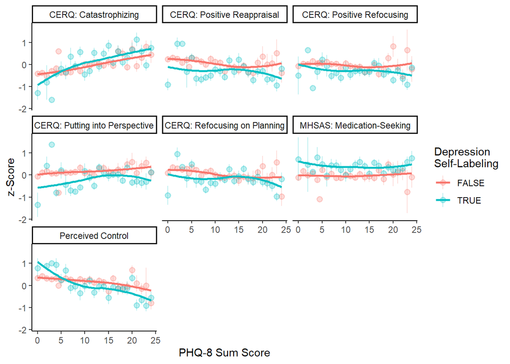

```r
df %>%
  pivot_longer(cols = c("perceived_control", "CERQ_catastrophizing", "CERQ_perspective", "CERQ_refocusing", "CERQ_reappraising", "CERQ_planning", "MHSAS_medication")) %>%
  mutate(name = recode(
    name,
    CERQ_acceptance = "CERQ: Acceptance",
    CERQ_catastrophizing = "CERQ: Catastrophizing",
    CERQ_other_blame = "CERQ: Other-Blame",
    CERQ_self_blame = "CERQ: Self-Blame",
    CERQ_perspective = "CERQ: Putting into Perspective",
    CERQ_planning = "CERQ: Refocusing on Planning",
    CERQ_reappraising = "CERQ: Positive Reappraisal",
    CERQ_refocusing = "CERQ: Positive Refocusing",
    CERQ_rumination = "CERQ: Rumination",
    MHSAS_medication = "MHSAS: Medication-Seeking",
    MHSAS_therapy = "MHSAS: Therapy-Seeking",
    perceived_control = "Perceived Control"
  )) %>%
  ggplot(aes(x = PHQ8, y = value, group = depression_self_id, color = depression_self_id)) +
  stat_summary(alpha = .25) +
  geom_smooth(method = "loess", formula = "y ~ x", span = 1, se = F) +
  scale_x_continuous(name = "PHQ-8 Sum Score") +
  scale_y_continuous(name = "z-Score") +
  scale_color_discrete(name = "Depression\nSelf-Labeling") +
  facet_wrap(~ name) +
  theme_classic()
```